# Analysis of 3k T cells from cancer

```python
%load_ext autoreload
%autoreload 2
import sys

sys.path.append("../..")
import scirpy as ir
import pandas as pd
import numpy as np
import scanpy as sc
from matplotlib import pyplot as plt
```

```python
adata = ir.datasets.wu2020_3k()
```

```python
adata.shape
```

```
(3000, 30727)
```

It just has additional TCR-related columns in `obs`:

```python
adata.obs
```

|  | TRA_1_c_gene | TRA_1_cdr3 | TRA_1_cdr3_len | TRA_1_cdr3_nt | TRA_1_d_gene | TRA_1_expr | TRA_1_j_gene | TRA_1_junction_ins | TRA_1_v_gene | TRA_2_c_gene | ... | TRB_2_junction_ins | TRB_2_v_gene | batch | clonotype_orig | cluster_orig | has_tcr | multi_chain | patient | sample | source |
| --- | --- | --- | --- | --- | --- | --- | --- | --- | --- | --- | --- | --- | --- | --- | --- | --- | --- | --- | --- | --- | --- |
| LN6_ACACCCTAGGCTAGAC-1-20 | TRAC | CAVLHNNNDMRF | 12.0 | TGTGCTGTGCTGCACAATAACAATGACATGCGCTTT | None | 3.0 | TRAJ43 | None | TRAV21 | None | ... | None | None | 20 | lung6.tnb.C4842 | 4.3-TCF7 | True | False | Lung6 | LN6 | NAT |
| LT1_ACTGAGTAGTGAAGTT-2-24 | TRAC | CASRISGNTPLVF | 13.0 | TGTGCTTCACGAATATCGGGAAACACACCTCTTGTCTTT | None | 5.0 | TRAJ29 | None | TRAV8-3 | TRAC | ... | None | None | 24 | lung1.tn.C21 | 4.6a-Treg | True | False | Lung1 | LT1 | Tumor |
| LN4_GTGCGGTAGAACTGTA-2-10 | TRAC | CAANL | 5.0 | TGTGCAGCAAACCTG | None | 1.0 | TRAJ28 | None | TRAV29DV5 | None | ... | None | None | 10 | lung4.tn.C4532 | 4.3-TCF7 | True | False | Lung4 | LN4 | NAT |
| ET1_TACTCATGTAGAAAGG-2-16 | None | None | NaN | None | None | NaN | None | None | None | None | ... | None | None | 16 | endo1.tn.C2569 | 4.1-Trm | True | False | Endo1 | ET1 | Tumor |
| LT4_GTACTCCTCCAGTAGT-2-17 | None | None | NaN | None | None | NaN | None | None | None | None | ... | None | None | 17 | lung4.tn.C53 | 8.2-Tem | True | False | Lung4 | LT4 | Tumor |
| ... | ... | ... | ... | ... | ... | ... | ... | ... | ... | ... | ... | ... | ... | ... | ... | ... | ... | ... | ... | ... | ... |
| LT5_TGGACGCTCTGGTGTA-1-9 | TRAC | CAVRPRGTSYDKVIF | 15.0 | TGTGCTGTGAGGCCCAGGGGGACCTCCTACGACAAGGTGATATTT | None | 3.0 | TRAJ50 | None | TRAV21 | None | ... | None | None | 9 | lung5.tn.C1929 | 4.1-Trm | True | False | Lung5 | LT5 | Tumor |
| LN3_GTAACTGGTACAGTGG-2-11 | TRAC | CADTGGSYIPTF | 12.0 | TGTGCAGACACTGGAGGAAGCTACATACCTACATTT | None | 1.0 | TRAJ6 | None | TRAV5 | None | ... | None | None | 11 | lung3.tn.C1040 | 8.3a-Trm | True | False | Lung3 | LN3 | NAT |
| RN2_GCCTCTATCTTCTGGC-1-27 | None | None | NaN | None | None | NaN | None | None | None | None | ... | None | None | 27 | renal2.tnb.C2862 | 4.2-RPL32 | True | False | Renal2 | RN2 | NAT |
| LT3_GTCGTAAGTTCCATGA-2-15 | None | None | NaN | None | None | NaN | None | None | None | None | ... | None | None | 15 | lung3.tn.C2161 | 3.1-MT | True | False | Lung3 | LT3 | Tumor |
| CT1_TACACGATCTCAAACG-1-13 | None | NONE | 4.0 | NONE | None | 1.0 | TRAJ58 | None | None | None | ... | None | None | 13 | colon1.tn.C1446 | 4.2-RPL32 | True | False | Colon1 | CT1 | Tumor |

3000 rows × 44 columns

## Preprocess Transcriptomics data

Transcriptomics data needs to be filtered and preprocessed as with any other single-cell dataset. We recommend following the [scanpy tutorial](https://scanpy-tutorials.readthedocs.io/en/latest/pbmc3k.html) and the best practice paper by [Luecken et al.](https://www.embopress.org/doi/10.15252/msb.20188746)

```python
sc.pp.filter_genes(adata, min_cells=10)
sc.pp.filter_cells(adata, min_genes=100)
```

```python
sc.pp.normalize_per_cell(adata, counts_per_cell_after=1000)
sc.pp.log1p(adata)
```

For the *Wu2020* dataset, the authors already provide clusters and UMAP coordinates. Instead of performing clustering and cluster annotation ourselves, we will just use provided data.

```python
adata.obsm["X_umap"] = adata.obsm["X_umap_orig"]
```

```python
mapping = {
    "3.1-MT": "other",
    "4.1-Trm": "CD4_Trm",
    "4.2-RPL32": "CD4_RPL32",
    "4.3-TCF7": "CD4_TCF7",
    "4.4-FOS": "CD4_FOSS",
    "4.5-IL6ST": "CD4_IL6ST",
    "4.6a-Treg": "CD4_Treg",
    "4.6b-Treg": "CD4_Treg",
    "8.1-Teff": "CD8_Teff",
    "8.2-Tem": "CD8_Tem",
    "8.3a-Trm": "CD8_Trm",
    "8.3b-Trm": "CD8_Trm",
    "8.3c-Trm": "CD8_Trm",
    "8.4-Chrom": "other",
    "8.5-Mitosis": "other",
    "8.6-KLRB1": "other",
}
adata.obs["cluster"] = [mapping[x] for x in adata.obs["cluster_orig"]]
```

Let's inspect the UMAP plots. The first three panels show the UMAP plot colored by sample, patient and cluster. We don't observe any clustering of samples or patients that could hint at batch effects.

The lower three panels show the UMAP colored by the T cell markers *CD8*, *CD4*, and *FOXP3*. We can confirm that the markers correspond to their respective cluster labels.

```
... storing 'cluster' as categorical
```

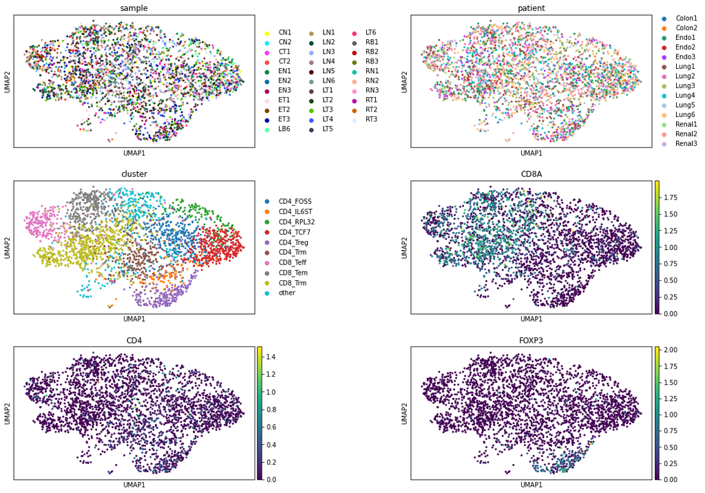

```python
sc.pl.umap(adata, color=["sample", "patient", "cluster", "CD8A", "CD4", "FOXP3"], ncols=2, wspace=.5)
```

## TCR Quality Control

### Compute CDR3 neighborhood graph

```python
ir.pp.tcr_neighbors(adata, strategy="all", chains="primary_only", cutoff=0)
ir.tl.define_clonotypes(adata)
```

```
... storing 'clonotype' as categorical
```

```
array([<matplotlib.axes._subplots.AxesSubplot object at 0x7fb4dcfc9f98>],
      dtype=object)
```

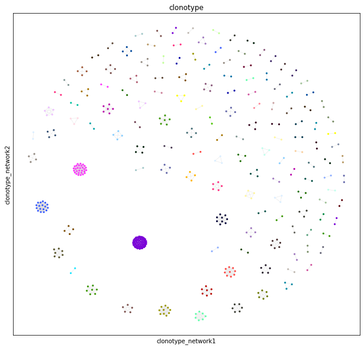

```python
ir.tl.clonotype_network(adata, min_size=2)
ir.pl.clonotype_network(adata, color="clonotype", legend_loc="none")
```

Let's re-compute the network with a `cutoff` of `20`. That's the equivalent of 4 `R`s mutating into `N` (using the BLOSUM62 distance matrix).

Additionally, we set `chains` to `all`. This results in the distances not being only computed between the most abundant pair of T-cell receptors, but instead, will take the minimal distance between any pair of T-cell receptors.

```python
ir.pp.tcr_neighbors(adata, cutoff=20, chains="all")
ir.tl.define_clonotypes(adata)
```

```python
ir.tl.clonotype_network(adata, min_size=3)
```

When coloring by clonotype, we can see that the large, connected Hairball has been sub-divided in multiple clonotypes by Graph-based clustering using the *Leiden-algorithm*. Also, the edges are now colored according to the distance between nodes. The darker an edge, the lower the alignment-distance.

```
... storing 'clonotype' as categorical
```

```
array([<matplotlib.axes._subplots.AxesSubplot object at 0x7fb4de7528d0>],
      dtype=object)
```

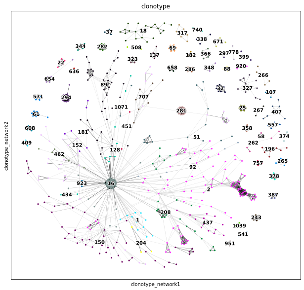

```python
ir.pl.clonotype_network(adata, color="clonotype", legend_fontoutline=2)
```

```
array([<matplotlib.axes._subplots.AxesSubplot object at 0x7fb4dc183438>],
      dtype=object)
```

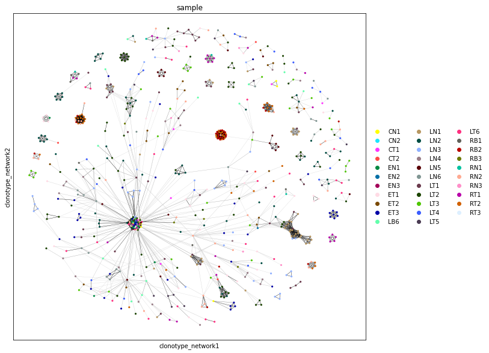

```python
ir.pl.clonotype_network(adata, color="sample")
```

Next, visualize the clonal expansion by cell-type cluster

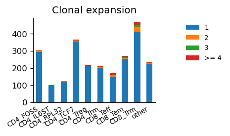

```python
ir.pl.clonal_expansion(adata, groupby="cluster", clip_at=4, fraction=False)
```

Normalized to the cluster size

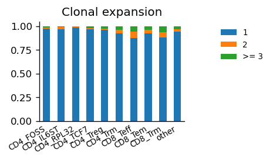

```python
ir.pl.clonal_expansion(adata, "cluster")
```

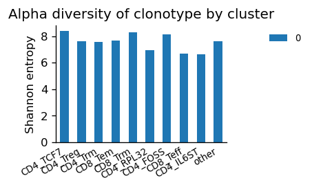

```python
ir.pl.alpha_diversity(adata, groupby="cluster")
```

### Clonotype abundance

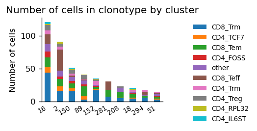

```python
ir.pl.group_abundance(
    adata, groupby="clonotype", target_col="cluster", max_cols=10, fraction=False
)
```

Perhaps an even more straightforward question would be comparing clonotype composition of samples

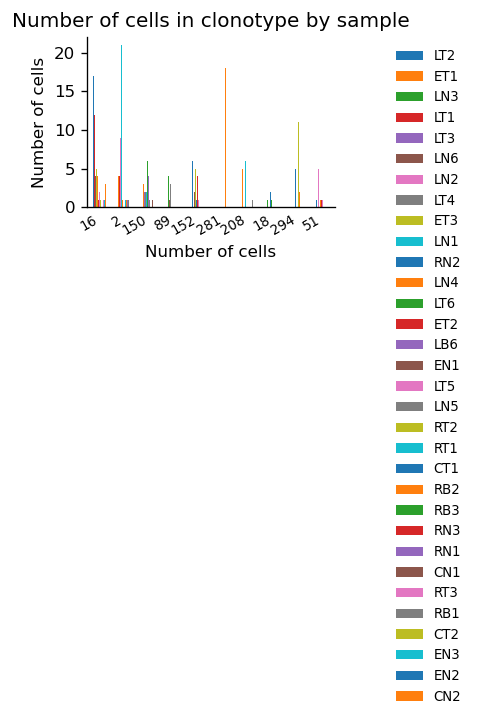

```python
ir.pl.group_abundance(
    adata, groupby="clonotype", target_col="sample", max_cols=10, stacked=False
)
```

If cell types are considered, it is still probably better to normalize to cell numbers in a sample.

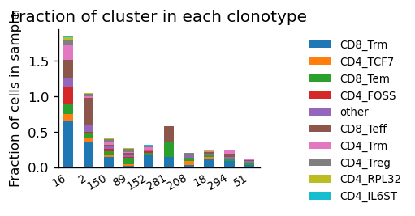

```python
ir.pl.group_abundance(
    adata, groupby="clonotype", target_col="cluster", fraction="sample", max_cols=10
)
```

## Gene usage

Group abundance plots can also give some information on VDJ usage

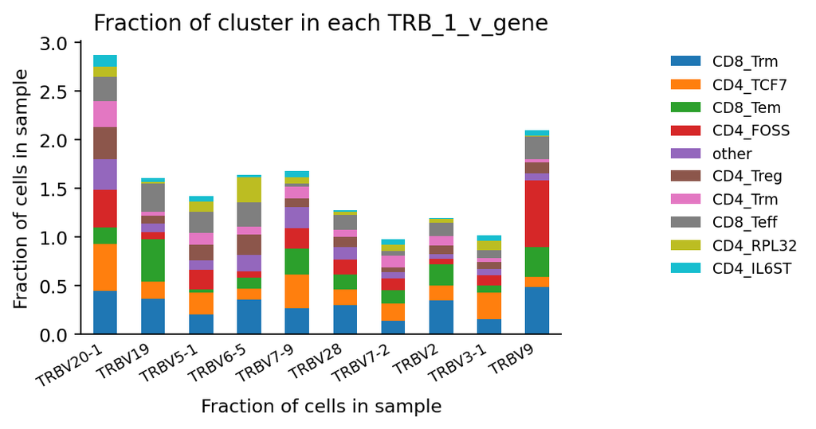

```python
ir.pl.group_abundance(
    adata,
    groupby="TRB_1_v_gene",
    target_col="cluster",
    fraction="sample",
    max_cols=10,
    fig_kws={"dpi": 170},
)
```

```python
vdj_usage = ir.tl.group_abundance(
    adata, groupby="cluster", target_col="TRB_1_v_gene", fraction=True
)
```

```python
vdj_usage = vdj_usage.loc[:, ["TRBV20-1", "TRBV7-2", "TRBV28", "TRBV5-1", "TRBV7-9"]]
```

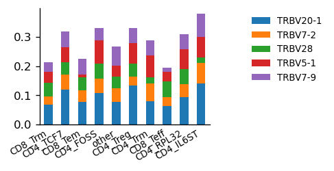

```python
ir.pl.base.bar(vdj_usage)
```

### Spectratype plots

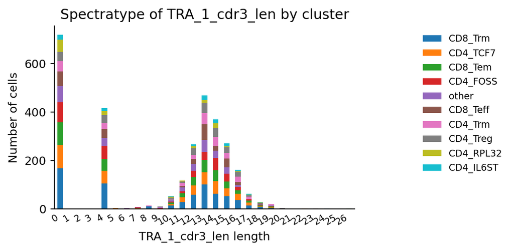

```python
ir.pl.spectratype(adata, target_col="cluster",     fig_kws={"dpi": 170},)
```

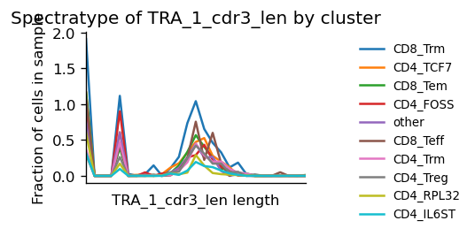

```python
ir.pl.spectratype(adata, target_col="cluster", fraction="sample", viztype="line")
```

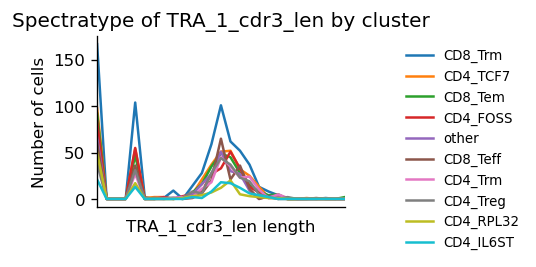

```python
ir.pl.spectratype(adata, target_col="cluster", fraction=False, viztype="line")
```

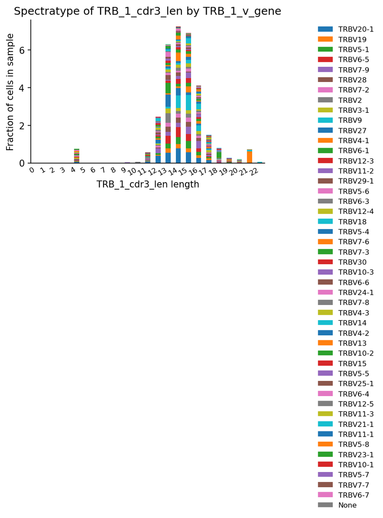

```python
ir.pl.spectratype(
    adata, groupby="TRB_1_cdr3_len", target_col="TRB_1_v_gene", fraction="sample", fig_kws={'dpi': 150}
)
```

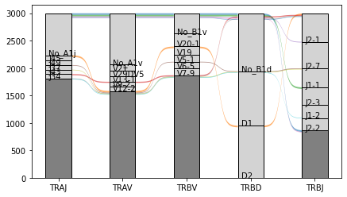

```python
ir.pl.vdj_usage(adata)
```

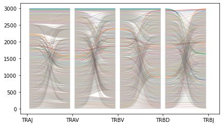

```python
ir.pl.vdj_usage(adata, top_n=None, draw_bars=False)
```

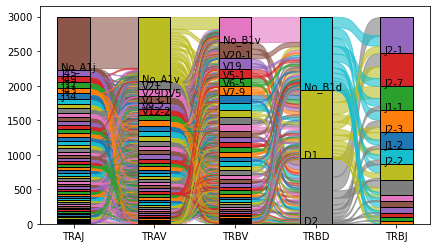

```python
ir.pl.vdj_usage(adata, full_combination=False, top_n=None)
```

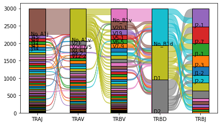

```python
ir.pl.vdj_usage(adata, full_combination=False, top_n=30)
```

subsetting adata: ir.pl.vdj_usage(adata[for_cells, :], ...)

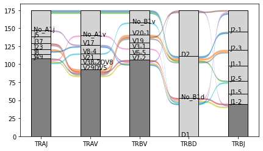

```python
ir.pl.vdj_usage(adata[adata.obs['sample'] == 'LT1'])
```

# Brainstorming

## Clonotype information on UMAP

Thinking with the head of future end users (wet lab researcher, focusing on the biology) I would anticipate a UMAP with the most abundant clonotypes and perhaps the V gene segments might be welcome.

```python
# This is probably hacky, we might think about a better way, but we need the most abundant clonotypes

top_clonotypes = adata.obs.clonotype.value_counts()[:8].index.values.tolist() # A better way might be needed especailly to take normalization into account
top_vgenes = adata.obs.TRB_1_v_gene.value_counts()[:8].index.values.tolist()
top_vgenes
```

```
['None',
 'TRBV20-1',
 'TRBV19',
 'TRBV5-1',
 'TRBV6-5',
 'TRBV7-9',
 'TRBV28',
 'TRBV7-2']
```

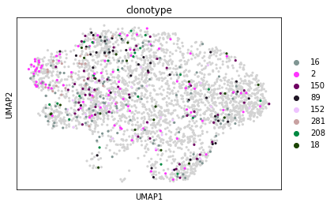

```python
sc.pl.umap(adata, color="clonotype", groups=top_clonotypes)
```

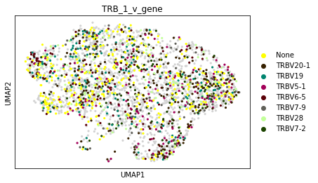

```python
sc.pl.umap(adata, color="TRB_1_v_gene", groups=top_vgenes)
```

```python
# The multipanel version does not work this way unfortuanately
sc.pl.umap(adata, color=["clonotype", "source", "cluster", "TRB_1_v_gene"], groups=[top_clonotypes, None, None, top_vgenes], ncols=2, wspace=.5)
```

[output not shown]

## Clonotype size and expansion for samples

Scanpy has the dotplot with dendrogram for genes, which I find pretty cool. I would imagine it a good chance to get some overview on the whole dataset to show samples, top clonotype, the size of those clonotypes and either the expansion or the publicness/privateness of that clonotype (later, when we have a nice measure for that)

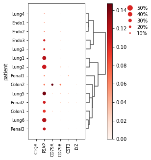

```
GridSpec(2, 5, height_ratios=[0, 10.5], width_ratios=[2.0999999999999996, 0.8, 0.2, 0.5, 0.25])
```

```python
# This would be the plot I want to reimplement, maybe without the denrogram now

sc.tl.dendrogram(adata, groupby='patient')
markers = ['C1QA', 'PSAP', 'CD79A', 'CD79B', 'CST3', 'LYZ']
sc.pl.dotplot(adata, markers, groupby='patient', dendrogram=True)
```

```python
# Subset adata for the top clonotypes

samples = adata.obs['sample'].unique()
clonotypes = adata.obs.clonotype.value_counts()[:25].index.values.tolist()
N, M = len(samples), len(clonotypes)
df = adata.obs.loc[adata.obs.clonotype.isin(clonotypes), ['clonotype', 'sample']].copy()
df['clonotype'] = df.clonotype.astype(str) # If clonotype column is categorical, it inherits all the categories, not only the top few -> compicates groupby
# More on the problem with categorical grouping: https://github.com/pandas-dev/pandas/issues/17594

df
```

|  | clonotype | sample |
| --- | --- | --- |
| LT1_ACTGAGTAGTGAAGTT-2-24 | 1 | LT1 |
| LN4_GTGCGGTAGAACTGTA-2-10 | 2 | LN4 |
| RB1_GTGCAGCCATCTCGCT-1-28 | 16 | RB1 |
| LT2_CTAGAGTCAGGGTACA-1-30 | 18 | LT2 |
| RN1_CGAGCACCACGTGAGA-1-1 | 22 | RN1 |
| ... | ... | ... |
| LN3_CTTGGCTCAGATGGCA-2-11 | 89 | LN3 |
| RB1_AAGGTTCGTGAGTGAC-1-28 | 22 | RB1 |
| RN2_ACACCCTTCTAGCACA-1-27 | 16 | RN2 |
| RB2_ACAGCTATCAACACCA-1-12 | 281 | RB2 |
| LN3_GTAACTGGTACAGTGG-2-11 | 128 | LN3 |

576 rows × 2 columns

```python
# We need weight column for aggregation

df['normalized_weight'] = 1
df = df.groupby(['clonotype', 'sample']).agg({'normalized_weight': 'sum'}).reset_index()
df['normalized_weight'] = df['normalized_weight'].fillna(0)

df
```

|  | clonotype | sample | normalized_weight |
| --- | --- | --- | --- |
| 0 | 1 | CN1 | 0.0 |
| 1 | 1 | CN2 | 0.0 |
| 2 | 1 | CT1 | 1.0 |
| 3 | 1 | CT2 | 0.0 |
| 4 | 1 | EN1 | 1.0 |
| ... | ... | ... | ... |
| 795 | 89 | RN2 | 0.0 |
| 796 | 89 | RN3 | 0.0 |
| 797 | 89 | RT1 | 0.0 |
| 798 | 89 | RT2 | 0.0 |
| 799 | 89 | RT3 | 0.0 |

800 rows × 3 columns

```python
# Try to order clonotypes reasonably

df['clonotype_rank'] = df['clonotype'].map(dict(list(zip(*[clonotypes, range(len(clonotypes))]))))
df = df.sort_values(by='clonotype_rank', ascending=False)
df
```

|  | clonotype | sample | normalized_weight | clonotype_rank |
| --- | --- | --- | --- | --- |
| 288 | 22 | CN1 | 0.0 | 24 |
| 304 | 22 | LN6 | 0.0 | 24 |
| 318 | 22 | RT2 | 0.0 | 24 |
| 317 | 22 | RT1 | 2.0 | 24 |
| 316 | 22 | RN3 | 0.0 | 24 |
| ... | ... | ... | ... | ... |
| 155 | 16 | RN2 | 5.0 | 0 |
| 156 | 16 | RN3 | 0.0 | 0 |
| 157 | 16 | RT1 | 4.0 | 0 |
| 158 | 16 | RT2 | 1.0 | 0 |
| 143 | 16 | LN5 | 1.0 | 0 |

800 rows × 4 columns

```python
# A little distraction, but color the background based on sample source

colordict = dict()
source_types = adata.obs.source.unique()
n_color = len(source_types)
tile_cols = int(len(plt.rcParams['axes.prop_cycle'].by_key()['color'])/n_color)
tile_cols = np.tile(plt.rcParams['axes.prop_cycle'].by_key()['color'], tile_cols+1)
for i in range(n_color):
    colordict[source_types[i]] = tile_cols[i]
print(colordict)

habillage = adata.obs.groupby(['sample', 'source']).agg('size').reset_index()
habillage = habillage.set_index('sample')
habillage = habillage['source'].to_dict()
```

```
{'NAT': '#1f77b4', 'Tumor': '#ff7f0e', 'Blood': '#2ca02c'}
```

```python
# Finally, add a measure for clonal expansion that will influence the color

rcm = plt.get_cmap('Reds')
dot_colors = ir.tl.clip_and_count(adata, "sample", target_col="clonotype").iloc[:,2].apply(lambda x: rcm(x+0.7))
dot_colors = np.tile(dot_colors, M) # This is cheating a bit, since now every dot has the same color in a column and it is wasting the opportunity to show more information
```

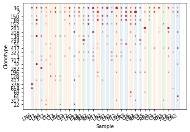

```python
# Draw a dotplot

x = np.tile(range(N), M)
y = np.repeat(range(M), N)
sizes = df['normalized_weight'].tolist()
fig, ax = plt.subplots()
ax.set_xticks(range(N))
ax.set_xticklabels(samples, rotation=30, ha='right')
ax.set_xlabel('Sample')
ax.set_yticks(range(M))
ax.set_yticklabels(clonotypes[::-1])
ax.set_ylabel('Clonotype')
ax.scatter(x, y, color=dot_colors, s=sizes)
for i in range(N):
    ax.axvspan(i-0.3, i+0.3, color=colordict[habillage[samples[i]]], alpha=0.1)
```

It would be even cooler if we had a measure for activation (a set of genes, like IL-2 and their mean expression?) and the color would correspond to how much activated (or anergic?) the cells in each clonotype are.